# Creating spatial polygons

Margot Schneider, Fonti Kar

2022-10-10

Being able to visualise and model where a species resides is an important skill, especially in conservation ecology. Here we’ll explain the difference between some commonly used methods for understanding species distributions and show you how to code them yourself! The methods in question are convex hulls and alpha hulls (don’t be alarmed it’s just simple shapes on a map!) which are used to [quantify IUCN metrics such as, Area of Occupancy and Extent of Occurrence](https://www.ala.org.au/spatial-portal-help/aoo/) to describe the distribution of a particular species. Typically, convex and alpha hulls are used when dealing with **data deficient species**.

Here, we will walk you through how to create and plot your own convex and alpha hulls using ALA data. We will also showcase some **recent research** that puts these spatial polygons to use for biodiversity conservation. These spatial visualizations are a great alternative to plotting point based species occurrence records!

We’ll start by installing/loading some R packages which we’ll need:

```r
#install.packages("pacman")

pacman::p_load(remotes, galah, tidyverse, alphahull, sp, sf, ozmaps, patchwork)
```

### An eye-catching example

We will use occurrence records of an endemic damselfly, *Austroargiolestes calcaris*, commonly known as the [Powdered Flatwing](https://bie.ala.org.au/species/https://biodiversity.org.au/afd/taxa/2d944503-2f03-48ec-8a8a-b78bc2b674af) to illustrate the various spatial polygons you can make

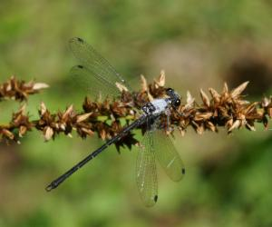

A Powdered Flatwing perched on a plant by Reiner Richter CC-BY 4.0

Lets use `galah` to download occurrence records from the [Atlas of Living Australia](https://www.ala.org.au/). Note that you will need to first set up your own [ALA configuration locally](http://galah.ala.org.au/articles/download_data.html?q=config#configuring-galah) using `galah_config` before fetching records.

```r
#Download Powdered flatwing records
galah_call() |>
  galah_identify("Austroargiolestes calcaris") |>
  galah_filter(profile="ALA") |>
  galah_select(group = "basic") |>
   atlas_occurrences() -> dfly
```

```
## This query will return 436 records
```

### Essential data cleaning

Before we can plot anything, we will first remove **all duplicates and missing values**!

```r
# De-duplication
dfly |>
  filter(! duplicated(decimalLongitude) & ! duplicated(decimalLatitude)) -> dfly_ddup

# Exclude NA in coordinates
dfly_ddup |>
  filter(! is.na(decimalLongitude) & ! is.na(decimalLatitude) ) -> dfly_clean
```

### Plot a convex hull of ALA occurences on a map!

Put simply a convex hull is a way to draw around all the points of a species on a map with as few lines as possible. It’s defined as the smallest polygon that encloses all the points in the data set. To plot a convex hull on a map, 1. We will start by using `chull()` to compute a convex hull from our cleaned Powdered Flatwing data. 2. We’ll then join the hull vector together to create an outline of the hull which can be plotted on a map. 3. To make a map we’ll use the `ozmaps` package and set it to a specific coordinate system for Australia. 4. Now we can plot our Powdered Flatwing occurrence records and its convex hull on a map!

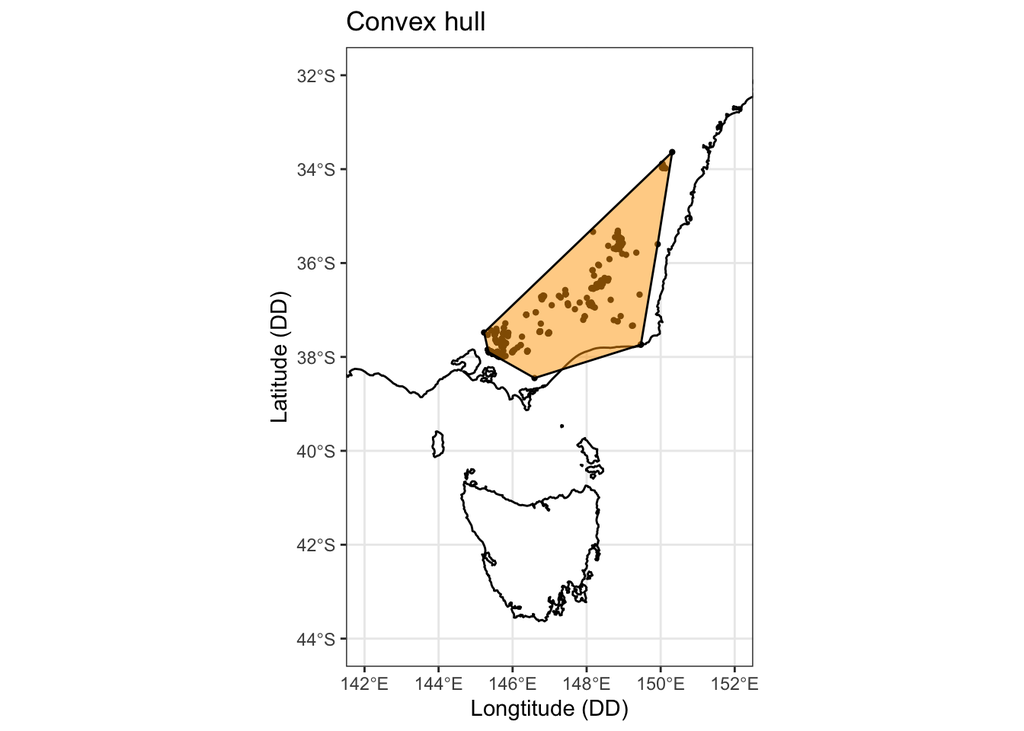

```r
# 1. Compute convex hull
dfly_clean |>
  select(decimalLongitude, decimalLatitude) |>
  chull() -> dfly_chull

# 2. Create the outline of the hull but joining the hull vector together
dfly_chull_pts <- c(dfly_chull, dfly_chull[1])

# 3. Getting a polygon of Australia and set it to a specific coordinate system
aus <- st_transform(ozmaps::ozmap_country, 4326)

# 4. Plot the occurrences and convex hull
ggplot() +
  geom_sf(data = aus, colour = "black", fill = "white")  +
  geom_point(data = dfly_clean, aes(decimalLongitude, decimalLatitude), colour = "black", size = 0.8) +
  geom_polygon(data = dfly_clean[dfly_chull_pts, ], aes(decimalLongitude, decimalLatitude), fill = "orange", colour = "black", alpha = 0.5) +
  coord_sf(xlim=c(142, 152),ylim=c(-32,-44)) +
  labs(title = "Convex hull", x = "Longtitude (DD)", y = "Latitude (DD)") + ## DD here stands for decimal degrees
  theme_bw() -> dfly_chull_p

dfly_chull_p
```

### Alpha shapes of ALA occurences

A convex hull is actually a simplified form of an *alpha shape*. Alpha shapes have an *alpha parameter* that controls the level of detail, or how tightly the boundary fits around the point set.

Lets make some alpha shapes for the Powdered Flatwing with increasing values of alpha. In order to do this we first need to use the `purrr` R package and a customised function named `extract_polygons` for extracting the polygon outline from an `ashape` object so we can plot it with `ggplot2`.

```r
extract_polygons <- function(alpha_shape_obj)
{
  if(class(alpha_shape_obj) != "ashape") stop("extract_polygons requires an ashape")
  edge.df <- as.data.frame(alpha_shape_obj$edges)
  groups <- ns <- xs <- ys <- numeric(nrow(edge.df))
  m <- cbind(edge.df[[1]], edge.df[[2]])
  group <- 1
  repeat {
    i <- which(groups == 0)[1]
    if (length(i) == 0 | is.na(i)) break()
    j <- n <- 1
    repeat {
      groups[i] <- group
      ns[i] <- n
      if(j == 1) xs[i] <- edge.df$x1[i] else xs[i] <- edge.df$x2[i]
      if(j == 1) ys[i] <- edge.df$y1[i] else ys[i] <- edge.df$y2[i]
      next_ind <- which((m[, j] == m[i, j] | m[, (j %% 2 + 1)] == m[i, j]) & groups == 0)
      if (length(next_ind) == 0) break()
      j <- which(m[next_ind,] == m[i, j]) %% 2 + 1
      i <- next_ind
      n <- n + 1
    }
    group <- group + 1
  }
  data.frame(x = xs, y = ys, group = as.factor(groups))[order(groups, ns), ]
}
```

Now that we have a function for extracting polygon outlines from an`ashape` object we can use our Powdered Flatwing data to make and plot those alpha shapes! To do this we’ll 1. compute our alpha shapes and store them within a tibble. 2. extract our polygons 3. plot our alpha shapes with occurrence points, just like we did for the convex hull above!

You’ll notice from the 3 plots below that as the alpha value gets larger, the more simplified the alpha shape becomes.You also might have noticed that alpha = 2 and alpha = 5 are very similar, this won’t always be the case, it’s going to vary based on the distribution of your data. **Alpha = 2** is what we’ve most commonly come across in research, and is the value recommended by the IUCN for various forms of species vulnerability analysis. This doesn’t mean other alpha values are useless, it just depends what you want to use it for!

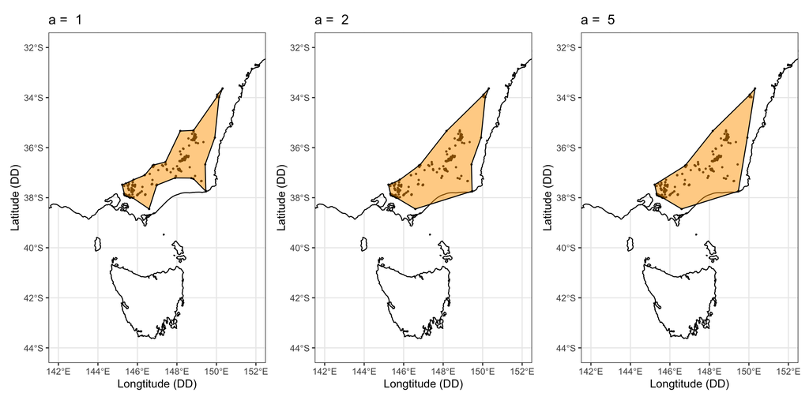

```r
# 1. Compute alpha shapes and store in list column within a tibble
tibble(
  alpha_value = c(1, 2, 5),
  ashape_ls = map(.x = c(1, 2, 5),
               .f = ~ dfly_clean |>
                 select(decimalLongitude, decimalLatitude) |>
                 ashape(alpha = .x))
) -> dfly_ashapes


# 2. Extract polygons
dfly_ashapes |>
  mutate(ashape_polygons = map(.x = ashape_ls,
                               .f = extract_polygons)) -> dfly_ashapes

# 3. Plot alpha shapes with occurrence points

##  A function to compose map
plot_ashape_fun <- function(polygon_data, title){
  p <- ggplot() +
    geom_sf(data = aus, colour = "black", fill = "white")  +
    geom_point(data = dfly_clean, aes(decimalLongitude, decimalLatitude), size = 0.5) +
    geom_polygon(data = polygon_data, aes(x, y), fill = "orange", colour = "black", alpha = 0.5) +
    coord_sf(xlim=c(142, 152),ylim=c(-32,-44)) +
    ggtitle(paste("a = ", as.character(title))) +
    labs(x = "Longtitude (DD)", y = "Latitude (DD)") +
    theme_bw(base_size = 12)
}

dfly_ashapes |>
  mutate(ashape_maps = map2(.x = ashape_polygons,
                            .y = alpha_value,
                            .f = ~ plot_ashape_fun(.x , .y))
         ) -> dfly_ashapes

wrap_plots(dfly_ashapes$ashape_maps)
```

### Alpha hull of ALA occurrences

Alpha hulls have arched edges, they are an extension of alpha shapes. The arched edges allow the shape to fit around the occurrence records more tightly. Even though the below plot has an alpha value of 2, the arched edges have it resembling the alpha shape where alpha = 1 in the plot above. To make our alpha hulls with ALA occurrence records we will rely on an R package `hull2spatial` developed by Cecina Babich Morrow. Check out their [blog post](https://babichmorrowc.github.io/post/2019-03-18-alpha-hull/) on how the package was made. The package allows us to convert `ahull` objects into ggplot-friendly objects. You can install the package using the code below:

```r
# install.packages("remotes)
remotes::install_github("babichmorrowc/hull2spatial")
```

To make and plot our alpha hull 1. We’ll start by taking our cleaned Powdered Flatwing records and turning it into an `sf` object. 2. Again taking our cleaned Powdered Flatwing data we will compute an alpha hull. 3. Taking that alpha hull we’ll transform it into an `sp` object 4. we can then transform the `sp` object into an `sf` object. 5. Lastly we’ll set our coordinates in preparation to plot it.

```r
# 1. Turn ALA occurrence data into a `sf` object
dfly_clean |>
  st_as_sf(coords = c("decimalLongitude", "decimalLatitude"), crs = 4326) -> dfly_sf

# 2. Compute an alpha hull for our occurrences
dfly_clean |>
  select(decimalLongitude, decimalLatitude) |>
  ahull(alpha = 2) -> dfly_ahull

# 3. Transform our `ahull` object into a `sp` object
hull2spatial::ahull2poly(dfly_ahull) -> dfly_sp_df

# 4. Transform `sp` object into a `sf` object
dfly_sp_df |>
  st_as_sf() -> dfly_sf_ahull

# 5. Set the coordinate system using `aus` object
dfly_sf_ahull %>% st_set_crs(st_crs(aus)) -> dfly_sf_ahull
```

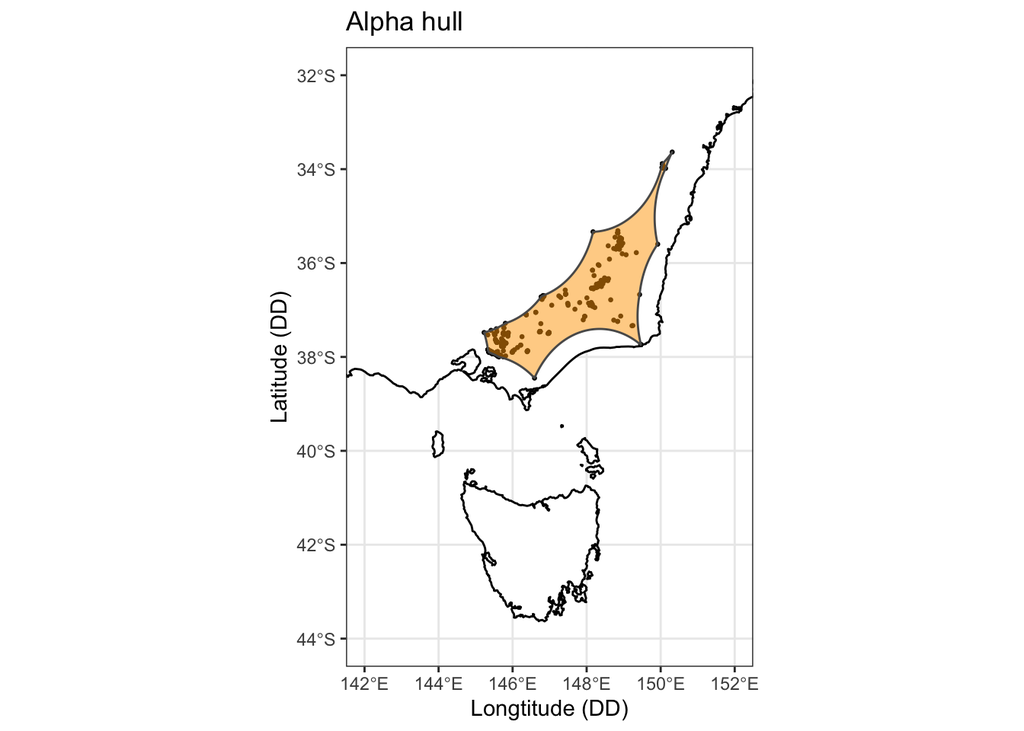

```r
# Plot the occurrences and alpha hull
ggplot() +
  geom_sf(data = aus, colour = "black", fill = "white")  +
  geom_sf(data = dfly_sf, colour = "black", size = 0.5) +
  geom_sf(data = dfly_sf_ahull, fill = "orange", alpha = 0.5) +
  coord_sf(xlim=c(142, 152),ylim=c(-32,-44)) +
  ggtitle("Alpha hull") +
  labs(x = "Longtitude (DD)", y = "Latitude (DD)") +
  theme_bw() -> dfly_ahull_p

dfly_ahull_p
```

### Alpha hull of ALA occurrences using specimen data

Often citizen science data are excluded from scientific analyses due to a reputation of poor data quality. By excluding citizen science data for the Powdered Flatwing our number of records drop significantly. Although we’ve lost more than half our records we can still compute and plot alpha hulls - this is the beauty of them!

We are going to repeat the above steps for generating an alpha hull, but we’ll **exclude citizen science data**. All the steps we went through to make out first alpha hull are the same, apart from an initial filter when we download the data.

```r
# Create a vector excluding human observations
institution_only <- c("PRESERVED_SPECIMEN", "LIVING_SPECIMEN",
                   "MACHINE_OBSERVATION", "MATERIAL_SAMPLE", "OBSERVATION")

galah_call() |>
  galah_identify("Austroargiolestes calcaris") |>
  galah_filter(basisOfRecord == institution_only,
               profile = "ALA") |>
  galah_select(group = "basic") |>
   atlas_occurrences() -> dfly_specionly
```

```
## This query will return 161 records
```

You’ll notice with this map that there are **two separate hulls** this is a benefit of an alpha hull over a convex hull: the mathematical constraints of a convex hull mean all the points must be contained within a single shape-this can lead to an over-estimation of range. The flip side of that is an alpha hull could be under-estimating range..pick your poison!

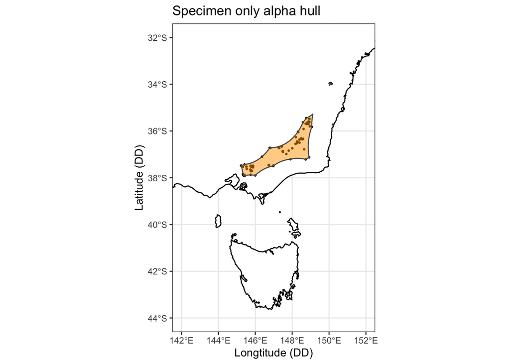

```r
ggplot() +
  geom_sf(data = aus, colour = "black", fill = "white")  +
  geom_sf(data = dflysp_sf, colour = "black", size = 0.5) +
  geom_sf(data = dflysp_sf_ahull, fill = "orange", alpha = 0.5) +
  coord_sf(xlim=c(142, 152),ylim=c(-32,-44)) +
  ggtitle("Specimen only alpha hull") +
  labs(x = "Longtitude (DD)", y = "Latitude (DD)") +
  theme_bw() -> dflysp_ahull_p

dflysp_ahull_p
```

### Alpha hulls in Biodiversity Research

Ok, so now we can create convex hulls, alpha shapes and alpha hulls using data from `galah` in R, what application does this have?

Recently, [Dr. Marsh and colleages](https://onlinelibrary.wiley.com/doi/full/10.1111/geb.13550) used alpha hulls to calculate the impact the 2020 mega bush fires on invertebrates in southern Australia. This research was the impetus for this post because invertebrate data is inherently sparse so alpha hulls can be helpful when you only have a handful of records to work with.

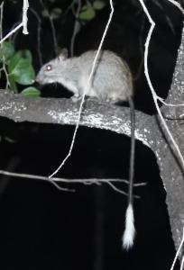

A Black-Footed Tree Rat perched on a branch by Colin Trainor CC-BY-NC 4.0

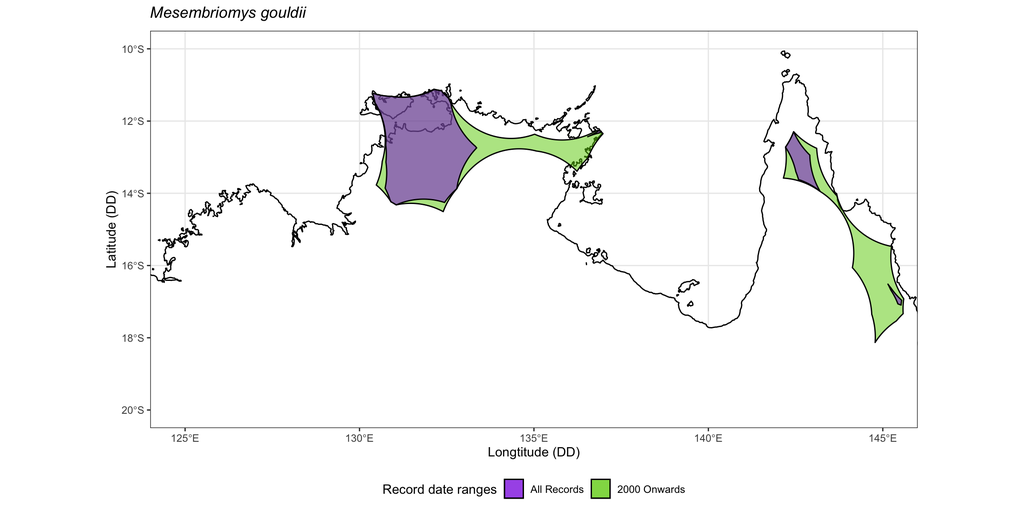

```r
# Nice title
rat_title <- expression(italic("Mesembriomys gouldii "), "alpha hulls")

ggplot() +
  geom_sf(data = aus, colour = "black", fill = "white")  +
  geom_sf(data = tree_rat_sf_ahull, aes(fill = "chartreuse3") ,alpha = 0.5, colour = "black", position = "identity") +
    geom_sf(data = Rtree_rat_sf_ahull, aes(fill = "blueviolet"), alpha = 0.5, colour = "black", position = "identity") +
  scale_fill_identity(guide = "legend",
                      name = "Record date ranges",
                      labels = c('All Records','2000 Onwards')) +
  guides(colour = guide_legend(override.aes = list(alpha = 0.1))) +
  coord_sf(xlim=c(125, 145),ylim=c(-20,-10)) +
  ggtitle(rat_title) +
  labs(x = "Longtitude (DD)", y = "Latitude (DD)") +
  theme_bw() +
  theme(legend.position = "bottom") -> combinedtree_rat_ahull_p

combinedtree_rat_ahull_p
```

Now we know how to make nice alpha hulls of our favourite species! This is a much clearer way of showing shifts in distribution that simply plotting occurrence records on a map.There are more sophisticated tools for understanding the distribution of species: like species distribution models. Sometimes you need more data then you have access to in order to run these models and this is when alpha hulls could be a good alternative.